# R Notebook

**Principles of Data Visualization and Introduction to ggplot2**

I have provided you with data about the 5,000 fastest growing companies in the US, as compiled by Inc. magazine. lets read this in:

```r
suppressMessages(library (funModeling)); suppressMessages(library (ggplot2)); suppressMessages(library(dplyr))  #load libraries
```

```r
inc <- read.csv("https://raw.githubusercontent.com/charleyferrari/CUNY_DATA_608/master/module1/Data/inc5000_data.csv", header= TRUE)
```

And lets preview this data:

```r
head(inc)
```

|  | Rank | Name | Growth_Rate | Revenue | Industry | Employees | City | State |
| --- | --- | --- | --- | --- | --- | --- | --- | --- |
| 1 | 1 | Fuhu | 421.48 | 1.179e+08 | Consumer Products & Services | 104 | El Segundo | CA |
| 2 | 2 | FederalConference.com | 248.31 | 4.960e+07 | Government Services | 51 | Dumfries | VA |
| 3 | 3 | The HCI Group | 245.45 | 2.550e+07 | Health | 132 | Jacksonville | FL |
| 4 | 4 | Bridger | 233.08 | 1.900e+09 | Energy | 50 | Addison | TX |
| 5 | 5 | DataXu | 213.37 | 8.700e+07 | Advertising & Marketing | 220 | Boston | MA |
| 6 | 6 | MileStone Community Builders | 179.38 | 4.570e+07 | Real Estate | 63 | Austin | TX |

```r
NA
```

```r
summary(inc)
```

```
      Rank                          Name       Growth_Rate         Revenue
 Min.   :   1   (Add)ventures         :   1   Min.   :  0.340   Min.   :2.000e+06
 1st Qu.:1252   @Properties           :   1   1st Qu.:  0.770   1st Qu.:5.100e+06
 Median :2502   1-Stop Translation USA:   1   Median :  1.420   Median :1.090e+07
 Mean   :2502   110 Consulting        :   1   Mean   :  4.612   Mean   :4.822e+07
 3rd Qu.:3751   11thStreetCoffee.com  :   1   3rd Qu.:  3.290   3rd Qu.:2.860e+07
 Max.   :5000   123 Exteriors         :   1   Max.   :421.480   Max.   :1.010e+10
                (Other)               :4995
                         Industry      Employees                  City
 IT Services                 : 733   Min.   :    1.0   New York     : 160
 Business Products & Services: 482   1st Qu.:   25.0   Chicago      :  90
 Advertising & Marketing     : 471   Median :   53.0   Austin       :  88
 Health                      : 355   Mean   :  232.7   Houston      :  76
 Software                    : 342   3rd Qu.:  132.0   San Francisco:  75
 Financial Services          : 260   Max.   :66803.0   Atlanta      :  74
 (Other)                     :2358   NA's   :12        (Other)      :4438
     State
 CA     : 701
 TX     : 387
 NY     : 311
 VA     : 283
 FL     : 282
 IL     : 273
 (Other):2764
```

Think a bit on what these summaries mean. Use the space below to add some more relevant non-visual exploratory information you think helps you understand this data:

** I use the df_status function to view missing values, zero valyes and infinite numbers. This is important as we want to have a dataset with at least 80% non-NA values and any variables with less than 50 unique values.

```r
df_status(inc) # using funModeling package, view variable metrics such as zeros, missing values and infinite numbers
```

| variable | q_zeros | p_zeros | q_na | p_na | q_inf | p_inf | type | unique |
| --- | --- | --- | --- | --- | --- | --- | --- | --- |
| Rank | 0 | 0 | 0 | 0.00 | 0 | 0 | integer | 4999 |
| Name | 0 | 0 | 0 | 0.00 | 0 | 0 | factor | 5001 |
| Growth_Rate | 0 | 0 | 0 | 0.00 | 0 | 0 | numeric | 1147 |
| Revenue | 0 | 0 | 0 | 0.00 | 0 | 0 | numeric | 1069 |
| Industry | 0 | 0 | 0 | 0.00 | 0 | 0 | factor | 25 |
| Employees | 0 | 0 | 12 | 0.24 | 0 | 0 | integer | 691 |
| City | 0 | 0 | 0 | 0.00 | 0 | 0 | factor | 1519 |
| State | 0 | 0 | 0 | 0.00 | 0 | 0 | factor | 52 |

```r
NA
```

## Question 1

Create a graph that shows the distribution of companies in the dataset by State (ie how many are in each state). There are a lot of States, so consider which axis you should use. This visualization is ultimately going to be consumed on a ‘portrait’ oriented screen (ie taller than wide), which should further guide your layout choices.

** For this problem, after counting up the companies in each state, we can see the top states with the most fastest growing companies: CA, TX and NY, with CA having almost 700 of them!

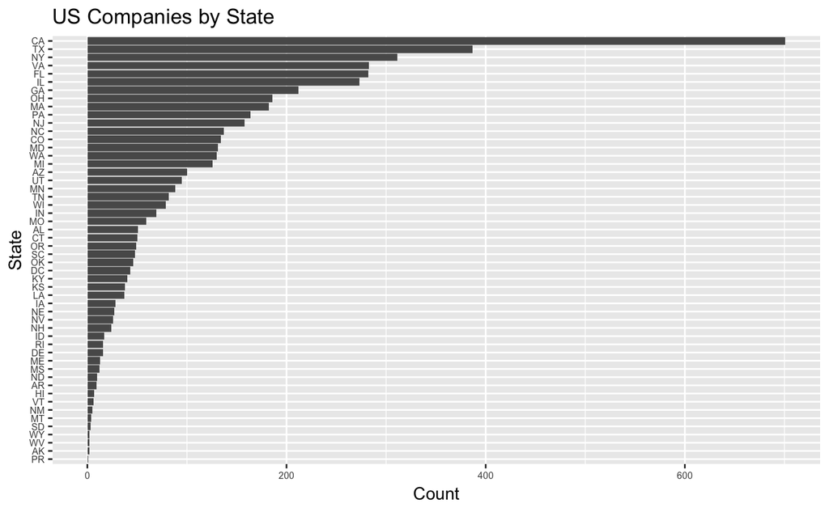

```r
#count up
data_1 <- inc %>%
  select (Name,State) %>%
  group_by(State) %>%
  summarise(count = n_distinct(Name))

ggplot(data_1, aes(reorder(State,count),count) )+ geom_bar(stat="identity") + labs(title = "US Companies by State",x = "State", y = "Count") + theme(axis.text.x = element_text(size=6),
          axis.text.y = element_text(size=6)) + coord_flip()
```

## Question 2

Lets dig in on the state with the 3rd most companies in the data set. Imagine you work for the state and are interested in how many people are employed by companies in different industries. Create a plot that shows the average and/or median employment by industry for companies in this state (only use cases with full data, use R’s `complete.cases()` function.) In addition to this, your graph should show how variable the ranges are, and you should deal with outliers.

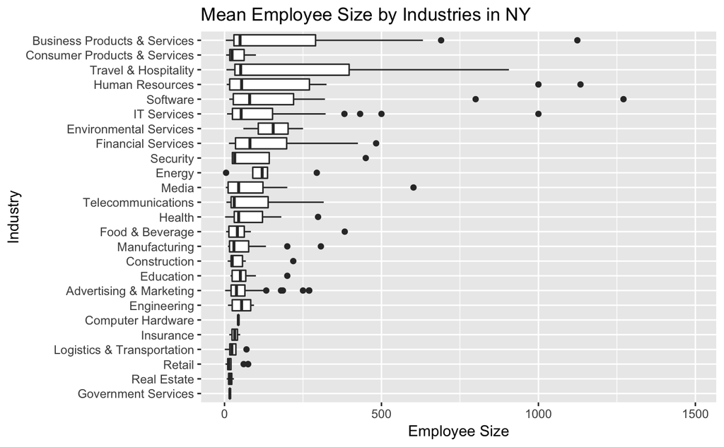

```r
#filter data for state == NY only
data_2<-inc %>%
  filter(State == "NY")

#use complete cases only from new filtered data
data_2 <- data_2[complete.cases(data_2$Industry), ]
data_2 <- data_2[complete.cases(data_2$Employees), ]

#mean employee by industry
m <- aggregate(Employees ~ Industry, data_2, mean)

#upper limit for graph
max <- max(m$Employees)

#plot graph with outliers
ggplot(data_2, aes(reorder(Industry, Employees, mean), Employees))+ geom_boxplot()  + coord_flip() + labs(title="Mean Employee Size by Industries in NY",x = "Industry", y = "Employee Size") + scale_y_continuous(limits = c(0,max))
```

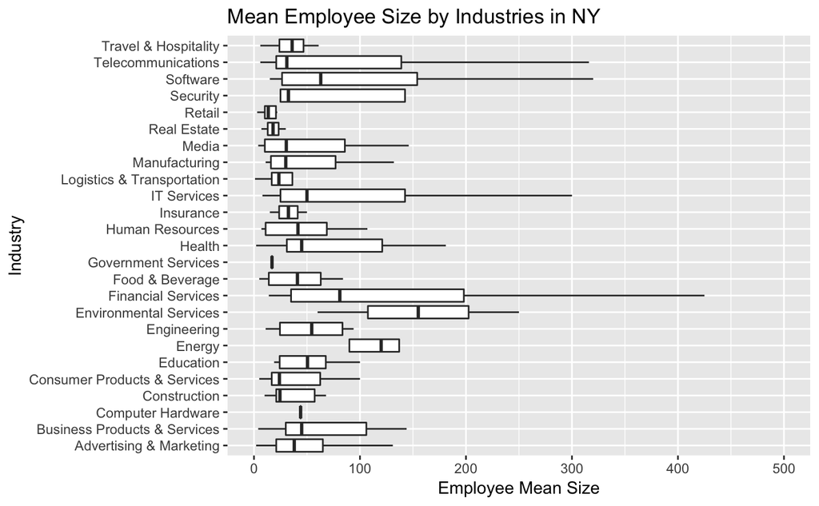

```r
#lets remove the outliers
data_2_adj <- data_2 %>%
  filter(Employees < 500)

#graph w/ outliers removed
ggplot(data_2_adj, aes(Industry, Employees)) + geom_boxplot(outlier.shape = NA) + coord_flip() + labs(title="Mean Employee Size by Industries in NY",x = "Industry", y = "Employee Mean Size") + scale_y_continuous(limits = c(0,500))
```

## Question 3

Now imagine you work for an investor and want to see which industries generate the most revenue per employee. Create a chart that makes this information clear. Once again, the distribution per industry should be shown.

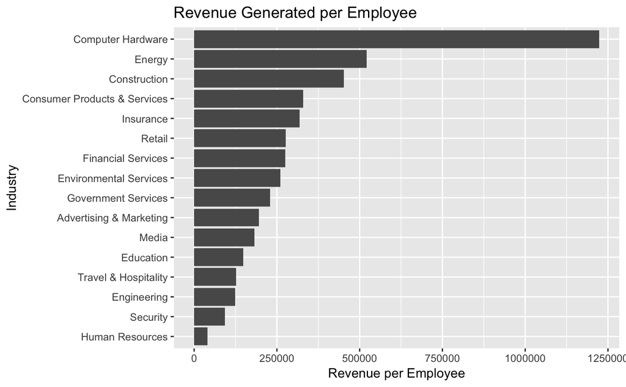

```r
#calculate the revenue per employee by industry
data_3 <- inc %>%
  select (Revenue, Industry, Employees) %>%
  group_by(Industry) %>%
  summarise(rev_total = sum(Revenue), empl_total = sum(Employees)) %>%
  mutate(rev_empl = rev_total / empl_total) %>%
  arrange (rev_empl)

#consider the complete cases only
data_3 <- data_3[complete.cases(data_3$Industry), ]
data_3 <- data_3[complete.cases(data_3$empl_total), ]

#create bar plot with highest revenues at top
ggplot(data_3, aes(reorder(Industry, rev_empl), rev_empl)) +
  geom_bar(stat="identity")+
  coord_flip() +
  labs(title = "Revenue Generated per Employee",x = "Industry", y = "Revenue per Employee")
```